# Assignment 3: Incarceration

Tingyu Zheng

2/24/2022

## Introduction and Summary Information

### Introcution

In this assignment, I will be investigating incarceration rate and jail population of Black people and White people, throughout years and across regions. According to the documentary *13TH*, prison population had been on the rise since the 1970s, when Nixon began to focus on criminalizing drug use, particularly strict on Black folks. **13th Amendment** freed former enslaved people from slavery, but it does not grant freedom to those who are **criminals**. Thus, as pointed out in the documentary, people found loophole in the Amendment and started disproportionately put African Americans in jail. It is important for us to show this issue using data.

### Summary

First, the percentage of Black people in jail is 33.58%, which is much greater than the percentage of Black population in the US (13.48%). Regional difference is also huge. In 2018, difference in the proportion of the prison population of African American in the South and North is 13.27%, indicating that South has a higher incarceration rate of Black people. While the majority of incarcerated people are male, African American women also face harshly high incarceration rate, with a percentage of38.93%. Although the percentage has decrease by 3.22% since 1995, it is still way above the percentage of African American population.

## Trends Over Time Chart

The following chart shows the trends of jail population in 4 regions in the US. This chart aims to indicate if the jail population had increase from 1995 to 2015 and which region has the highest increase.

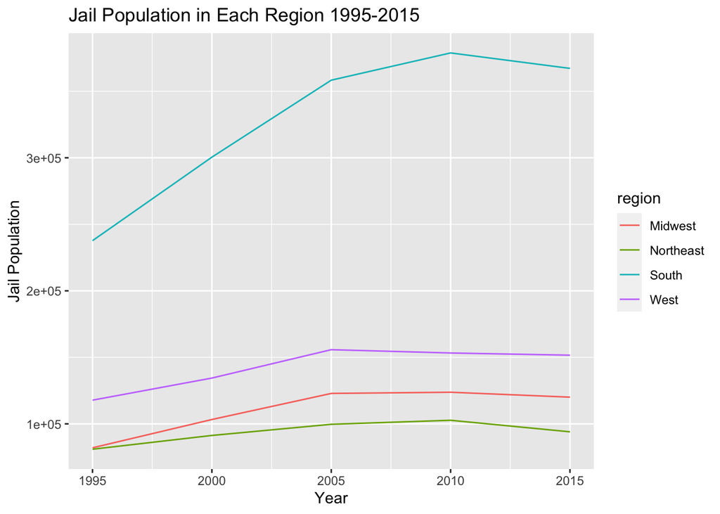

We can tell from the plot that jail population had all increased in the 4 regions. South has the largest increase compared to other regions.

## Variable Comparison Chart

In this chart, I compare total population and white population in jail, and see if they are correlated.

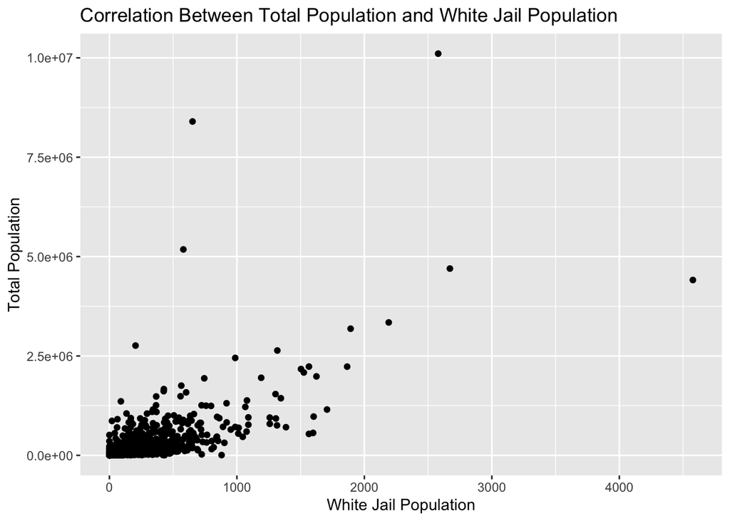

This chart shows that total population and White population in jail is generally positively correlated. However, there are still some outliers that has a steeper slope than the general trend. These locations might have worse racial disparity in incarceration.

## Map

The following map categorizes the incarceration rate of Black people by state.

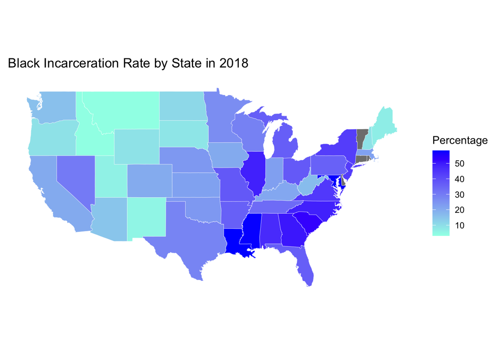

Overall, incarceration rate of Black people in the east is higher than in the west. There are also several southern states that have rates higher than 50%. According to the values given above, Black Americans only make up around 13% of the US population. Therefore, over half of the states in the US might have problems of over policing on Black people.